# Mini Project 2

Collins Kwasi Apenteng

2024-03-20

## Problem 1: Simple Linear Linear Regression Model

#### Steps 1 to 4

```r
# Step 1
beta0 = 2
beta1 = 3
sigma2 = 1.5
sigma = sqrt(sigma2)

# Step 2
n = 100
set.seed(18071)  # setting seed for reproducibility
X = rnorm(n, 5, 2)  # generating explanatory variable X
epsilon = rnorm(n, 0, sigma)  # generating random error ϵ

# Step 3: Using model 1, generate Y
Y = beta0 + beta1 * X + epsilon

# Step 4: Estimate the values of beta0, beta1, and sigma2
SSxy = sum((X - mean(X)) * (Y - mean(Y)))
SSxx = sum((X - mean(X))^2)
beta1_hat = SSxy / SSxx
beta0_hat = mean(Y) - beta1_hat * mean(X)
y_hat = beta0_hat + beta1_hat * X
SSE = sum((Y - y_hat)^2)
sigma2_hat = SSE / (n - 2)

cat("Estimated value of beta0_hat:", beta0_hat, "\n")
```

```
Estimated value of beta0_hat: 2.134482
```

```r
cat("Estimated value of beta1_hat:", beta1_hat, "\n")
```

```
Estimated value of beta1_hat: 2.968252
```

```r
cat("Estimated value of sigma2_hat:", sigma2_hat, "\n")
```

```
Estimated value of sigma2_hat: 1.970649
```

#### Step 5

```r
N = 1000
beta0_hat_values = vector()
beta1_hat_values = vector()
sigma2_hat_values = vector()

for (i in 1:N) {
  X = rnorm(n, mean = 5, sd = 2)
  epsilon = rnorm(n, mean = 0, sd = sigma)
  Y = beta0 + beta1 * X + epsilon

  SSxy = sum((X - mean(X)) * (Y - mean(Y)))
  SSxx = sum((X - mean(X))^2)
  beta1_hat = SSxy / SSxx
  beta0_hat = mean(Y) - beta1_hat * mean(X)
  y_hat = beta0_hat + beta1_hat * X
  SSE = sum((Y - y_hat)^2)
  sigma2_hat = SSE / (n - 2)

  beta0_hat_values[i] = beta0_hat # stores values of beta0_hata
  beta1_hat_values[i] = beta1_hat # stores values of beta1_hat
  sigma2_hat_values[i] = sigma2_hat # stores values of sigma2_hat
}
cat("First 10 values of beta0_hat:\n")
```

```
First 10 values of beta0_hat:
```

```r
print(head(beta0_hat_values, 10))
```

```
 [1] 1.831896 2.162680 1.635859 1.896140 2.628755 1.927110 2.242156 2.185534
 [9] 1.648970 1.512148
```

```r
cat("\nFirst 10 values of beta1_hat:\n")
```

```
First 10 values of beta1_hat:
```

```r
print(head(beta1_hat_values, 10))
```

```
 [1] 3.005327 3.010196 3.035700 2.998296 2.900122 3.012630 2.941143 2.965536
 [9] 3.039316 3.061436
```

```r
cat("\nFirst 10 values of sigma2_hat:\n")
```

```
First 10 values of sigma2_hat:
```

```r
print(head(sigma2_hat_values, 10))
```

```
 [1] 1.351110 1.381267 1.387067 1.133721 1.467926 1.467816 1.957481 1.286836
 [9] 1.724704 1.866338
```

#### Step 6

```r
avg_beta0_hat = mean(beta0_hat_values)
avg_beta1_hat = mean(beta1_hat_values)
avg_sigma2_hat = mean(sigma2_hat_values)

cat("Average value of beta0_hat:", avg_beta0_hat, "\n")
```

```
Average value of beta0_hat: 2.013032
```

```r
cat("Average value of beta1_hat:", avg_beta1_hat, "\n")
```

```
Average value of beta1_hat: 2.998042
```

```r
cat("Average value of sigma2_hat:", avg_sigma2_hat, "\n")
```

```
Average value of sigma2_hat: 1.506928
```

#### Step 7

```r
bias_beta0_hat = avg_beta0_hat - beta0
bias_beta1_hat = avg_beta1_hat - beta1
bias_sigma2_hat = avg_sigma2_hat - sigma2

cat("Bias of beta0_hat:", bias_beta0_hat, "\n")
```

```
Bias of beta0_hat: 0.01303176
```

```r
cat("Bias of beta1_hat:", bias_beta1_hat, "\n")
```

```
Bias of beta1_hat: -0.001958319
```

```r
cat("Bias of sigma2_hat:", bias_sigma2_hat, "\n")
```

```
Bias of sigma2_hat: 0.006927653
```

#### Step 8

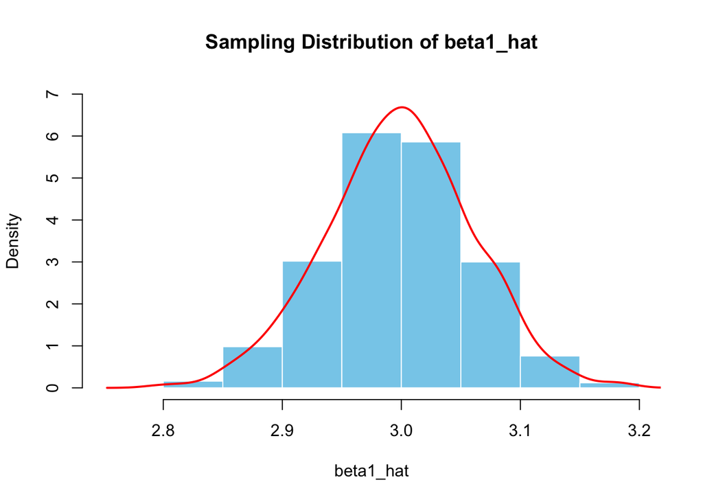

```r
hist(beta1_hat_values, freq = FALSE,
     main = "Sampling Distribution of beta1_hat",
     xlab = "beta1_hat", col = "skyblue", border = "white",
    ylim =  c(0,7) )
lines(density(beta1_hat_values), col = "red", lwd = 2)
```

#### Step 9

```r
empirical_var_beta1 = var(beta1_hat_values)
cat("Empirical Variance:", empirical_var_beta1, "\n")
```

```
Empirical Variance: 0.003793115
```

#### Step 10

```r
true_var_beta1 = sigma2/SSxx
cat("True Variance:", true_var_beta1, "\n")
```

```
True Variance: 0.003377931
```

#### Step 11

The empirical variance and the true variance are approximately equal suggesting beta1_hat is unbiased. This is also evident from the sampling distribution of beta1_hat in step 8 as most of the values of beta1_hat are concentrated around the true value (3) of beta1_hat.

## Problem 2: Multiple Linear Regression Model

#### Steps 1 to 4

```r
# Step 1
beta0 = 2
beta1 = 3
beta2 = -1
beta3 = 5

k = 3 # Number of predictors
sigma2 = 0.5
sigma = sqrt(sigma2)


# Step 2
n = 500
set.seed(123)  # for reproducibility
X1 = rnorm(n,  5, 2)
X2 = rnorm(n,  3, 1)
X3 = rnorm(n,  7, 3)

# Step 3
Y = beta0 + beta1 * X1 + beta2 * X2 + beta3 * X3 + epsilon

# Step4
intercept = rep(1, n)
X = cbind(intercept, X1, X2, X3)
beta_hat=solve(t(X) %*% X) %*% t(X) %*% Y

colnames(beta_hat)=c("coefficients")
beta_hat
```

```
          coefficients
intercept     2.446845
X1            2.949896
X2           -1.043334
X3            4.995319
```

#### Step 5

```r
Y_hat = X %*% beta_hat
e = Y - Y_hat
SSE = t(e) %*% e
sigma2_hat = SSE / (n - (k+1))
cat("The estimate of sigma2_hat:", sigma2_hat, "\n")
```

```
The estimate of sigma2_hat: 1.940499
```

#### Step 6

```r
options(scipen = 1000)
variance_beta_hat = sigma2 * (solve(t(X) %*% X))
round(variance_beta_hat, 6)
```

```
          intercept        X1        X2        X3
intercept  0.021724 -0.001360 -0.002971 -0.000696
X1        -0.001360  0.000266  0.000028 -0.000011
X2        -0.002971  0.000028  0.000986 -0.000018
X3        -0.000696 -0.000011 -0.000018  0.000114
```

#### Step 7

```r
df = n - (k+1) # where df represents degrees of freedom
t_critical = qt(0.975, df)

SE_beta_hat = sqrt(diag(variance_beta_hat))

# Confidence intervals for each coefficient
CI_beta = matrix(NA, nrow = 3, ncol = 2)  # Matrix to store confidence intervals
for (j in 1:3) {
  CI_beta[j, 1] = beta_hat[j] - t_critical * SE_beta_hat[j]
  CI_beta[j, 2] = beta_hat[j] + t_critical * SE_beta_hat[j]
}

cat("95% Confidence Intervals for beta1, beta2, beta3:\n")
```

```
95% Confidence Intervals for beta1, beta2, beta3:
```

```r
rownames(CI_beta) = c("beta1", "beta2", "beta3")
colnames(CI_beta) = c("Lower", "Upper")
print(CI_beta)
```

```
          Lower      Upper
beta1  2.157257  2.7364332
beta2  2.917825  2.9819668
beta3 -1.105030 -0.9816376
```

#### Step 8

```r
options(scipen = 10000)
model3 = lm(Y ~ X1 + X2 + X3)
summary(model3)
```

```
Call:
lm(formula = Y ~ X1 + X2 + X3)

Residuals:
    Min      1Q  Median      3Q     Max
-2.6595 -1.0909 -0.0310  0.9801  3.6617

Coefficients:
            Estimate Std. Error t value             Pr(>|t|)
(Intercept)  2.44685    0.29036   8.427 0.000000000000000387 ***
X1           2.94990    0.03216  91.734 < 0.0000000000000002 ***
X2          -1.04333    0.06186 -16.866 < 0.0000000000000002 ***
X3           4.99532    0.02100 237.834 < 0.0000000000000002 ***
---
Signif. codes:  0 '***' 0.001 '**' 0.01 '*' 0.05 '.' 0.1 ' ' 1

Residual standard error: 1.393 on 496 degrees of freedom
Multiple R-squared:  0.9928,    Adjusted R-squared:  0.9927
F-statistic: 2.267e+04 on 3 and 496 DF,  p-value: < 0.00000000000000022
```

The regression coefficients in model 3 are exactly the same as those computed in step 4. Also, the estimated sigma in step 5 is equal to the **square** of the **Residual standard error** in model 3.

#### Step 9

```r
SSE = sum((Y - Y_hat)^2)
cat("SSE:", SSE, "\n")
```

```
SSE: 962.4874
```

```r
SSR = sum((Y_hat - mean(Y))^2)
cat("SSR:", SSR, "\n")
```

```
SSR: 131974.1
```

```r
SST = sum((Y - mean(Y))^2)
cat("SST:", SST, "\n")
```

```
SST: 132936.6
```

```r
cat("SSE+SSR:", SSE+SSR, "\n")
```

```
SSE+SSR: 132936.6
```

We can affirm that the sum of SSE and SSR is equal to SST.

#### Step 10

```r
MSR = SSR / k
MSE = SSE / (n-(k+1))

F = MSR/MSE
cat("F Statistic:", F, "\n")
```

```
F Statistic: 22670.14
```

#### Step 11

```r
pf(F,k,n-(k+1), lower.tail=FALSE)
```

```
[1] 0
```

Conclusion: The model is significant. That is, the joint hypothesis that all the estimated coefficients are equal to zero is rejected.

#### Step 12

```r
R_square_adj = 1 - ((SSE/(n-(k+1)))/(SST/(n-1)))
cat("Adjusted R squared:", R_square_adj, "\n")
```

```
Adjusted R squared: 0.992716
```

Interpretation: approximately 99.3% of the variation in Y is explained by the three predictors X1, X2, and X3, after accounting for the number of predictors and the sample size

#### Step 13

```r
options(scipen = 10000000)
summary(model3)
```

```
Call:
lm(formula = Y ~ X1 + X2 + X3)

Residuals:
    Min      1Q  Median      3Q     Max
-2.6595 -1.0909 -0.0310  0.9801  3.6617

Coefficients:
            Estimate Std. Error t value             Pr(>|t|)
(Intercept)  2.44685    0.29036   8.427 0.000000000000000387 ***
X1           2.94990    0.03216  91.734 < 0.0000000000000002 ***
X2          -1.04333    0.06186 -16.866 < 0.0000000000000002 ***
X3           4.99532    0.02100 237.834 < 0.0000000000000002 ***
---
Signif. codes:  0 '***' 0.001 '**' 0.01 '*' 0.05 '.' 0.1 ' ' 1

Residual standard error: 1.393 on 496 degrees of freedom
Multiple R-squared:  0.9928,    Adjusted R-squared:  0.9927
F-statistic: 2.267e+04 on 3 and 496 DF,  p-value: < 0.00000000000000022
```

```r
anova(model3)
```

```
Analysis of Variance Table

Response: Y
           Df Sum Sq Mean Sq   F value                Pr(>F)
X1          1  22178   22178 11429.225 < 0.00000000000000022 ***
X2          1     31      31    15.978            0.00007381 ***
X3          1 109765  109765 56565.204 < 0.00000000000000022 ***
Residuals 496    962       2
---
Signif. codes:  0 '***' 0.001 '**' 0.01 '*' 0.05 '.' 0.1 ' ' 1
```

For the **SSR**, adding the sum of squares attributed to X1, X2, and X3 from the anova output, we get approximately the same SSR computed in step 9. For the **SSE**, the anova table shows Residual sum of squares approximately equal to the SSE from step 9. For the **SST**, adding all the sum of squares gives an estimate approximately equal to the SST obtained in step 9.

The **F statistic** displayed from summary of model3 is approximately equal to the one computed in step 10

The **p value** from the summary output is also equal to the one computed in step 11.

Finally, the **adjusted R squared** from the summary of model3 is equal to the one computed in step 12

## Problem 3: Continuation of Problem 2

#### Steps 1

```r
N = 1000
beta_hat_list = matrix(NA, nrow = N, ncol = 4)
sigma2_hat_list = numeric(N)
variance_beta_hat_list = array(NA, dim = c(N, 4, 4))
CI_beta_list = array(NA, dim = c(N, 4, 2))

# Performing 1000 simulations
for (i in 1:N) {
  # Step 2: Generate covariates X1, X2, and X3
  X1 = rnorm(n, 5, 2)
  X2 = rnorm(n, 3, 1)
  X3 = rnorm(n, 7, 3)

  # Step 3: Generate response variable Y
  Y = beta0 + beta1 * X1 + beta2 * X2 + beta3 * X3 + rnorm(n, 0, sigma)

  # Step 4: Calculate estimated coefficients beta_hat
  intercept = rep(1, n)
  X = cbind(intercept, X1, X2, X3)
  beta_hat = solve(t(X) %*% X) %*% t(X) %*% Y
  beta_hat_list[i,] = beta_hat

  # Step 5: Estimate sigma2_hat
  Y_hat = X %*% beta_hat
  e = Y - Y_hat
  SSE = t(e) %*% e
  sigma2_hat = SSE / (n - (k + 1))
  sigma2_hat_list[i] = sigma2_hat

  # Step 6: Estimate variance of beta_hat
  variance_beta_hat = sigma2 * solve(t(X) %*% X)
  variance_beta_hat_list[i,,] = variance_beta_hat

  # Step 7: Construct 95% confidence intervals for beta0, beta1, beta2, and beta3
  df = n - (k + 1)  # Degrees of freedom
  t_critical = qt(0.975, df)  # t-critical value

  SE_beta_hat = sqrt(diag(variance_beta_hat))

  # Confidence intervals for each coefficient
  CI_beta = matrix(NA, nrow = 4, ncol = 2)
  for (j in 1:4) {
    CI_beta[j, 1] = beta_hat[j] - t_critical * SE_beta_hat[j]
    CI_beta[j, 2] = beta_hat[j] + t_critical * SE_beta_hat[j]
  }
  CI_beta_list[i,,] = CI_beta
}
```

#### Step 2

```r
# Storing the values of beta_j_hat for j=1,2,3
beta1_hat_values = beta_hat_list[, 2]
beta2_hat_values = beta_hat_list[, 3]
beta3_hat_values = beta_hat_list[, 4]

cat("First 5 Values of beta1_hat:", beta1_hat_values[1:5], "\n")
```

```
First 5 Values of beta1_hat: 3.002971 3.006573 3.006984 3.014522 3.018847
```

```r
cat("First 5 Values of beta2_hat:", beta2_hat_values[1:5], "\n")
```

```
First 5 Values of beta2_hat: -0.9855869 -0.9698498 -0.970477 -0.9982607 -1.011445
```

```r
cat("First 5 Values of beta3_hat:", beta3_hat_values[1:5], "\n")
```

```
First 5 Values of beta3_hat: 5.00618 4.99547 4.999552 4.984156 4.975291
```

```r
# Calculating the averages of the stored beta hats
average_beta1_hat = mean(beta1_hat_values)
average_beta2_hat = mean(beta2_hat_values)
average_beta3_hat = mean(beta3_hat_values)

cat("Average of beta1_hat:", average_beta1_hat, "\n")
```

```
Average of beta1_hat: 2.999554
```

```r
cat("Average of beta2_hat:", average_beta2_hat, "\n")
```

```
Average of beta2_hat: -0.99879
```

```r
cat("Average of beta3_hat:", average_beta3_hat, "\n")
```

```
Average of beta3_hat: 4.999959
```

#### Step 3

```r
# Calculate the bias for each estimated coefficient
bias_beta1 = average_beta1_hat - beta1
bias_beta2 = average_beta2_hat - beta2
bias_beta3 = average_beta3_hat - beta3
bias_500n = c(bias_beta1, bias_beta2, bias_beta3)

cat("Bias for beta1:", bias_beta1, "\n")
```

```
Bias for beta1: -0.0004460904
```

```r
cat("Bias for beta2:", bias_beta2, "\n")
```

```
Bias for beta2: 0.001210016
```

```r
cat("Bias for beta3:", bias_beta3, "\n")
```

```
Bias for beta3: -0.00004140775
```

#### Step 4: Number of confidence intervals that capture the true values

```r
captured_intervals_beta1 = 0
captured_intervals_beta2 = 0
captured_intervals_beta3 = 0

for (i in 1:N) {
  if (CI_beta_list[i, 2, 1] <= beta1 && CI_beta_list[i, 2, 2] >= beta1) {
    captured_intervals_beta1 = captured_intervals_beta1 + 1
  }
  if (CI_beta_list[i, 3, 1] <= beta2 && CI_beta_list[i, 3, 2] >= beta2) {
    captured_intervals_beta2 = captured_intervals_beta2 + 1
  }
  if (CI_beta_list[i, 4, 1] <= beta3 && CI_beta_list[i, 4, 2] >= beta3) {
    captured_intervals_beta3 = captured_intervals_beta3 + 1
  }
}

cat("Number of captured intervals for Beta1:", captured_intervals_beta1, "\n")
```

```
Number of captured intervals for Beta1: 935
```

```r
cat("Number of captured intervals for Beta2:", captured_intervals_beta2, "\n")
```

```
Number of captured intervals for Beta2: 957
```

```r
cat("Number of captured intervals for Beta3:", captured_intervals_beta3, "\n")
```

```
Number of captured intervals for Beta3: 955
```

```r
# Calculate the percentage of captured intervals for each beta
coverage_prob_beta1 = captured_intervals_beta1 / N * 100
coverage_prob_beta2 = captured_intervals_beta2 / N * 100
coverage_prob_beta3 = captured_intervals_beta3 / N * 100
coverage_probs_500n = c(coverage_prob_beta1, coverage_prob_beta2, coverage_prob_beta3)

cat("Percentage of coverage for Beta1:", coverage_prob_beta1, "%\n")
```

```
Percentage of coverage for Beta1: 93.5 %
```

```r
cat("Percentage of coverage for Beta2:", coverage_prob_beta2, "%\n")
```

```
Percentage of coverage for Beta2: 95.7 %
```

```r
cat("Percentage of coverage for Beta3:", coverage_prob_beta3, "%\n")
```

```
Percentage of coverage for Beta3: 95.5 %
```

#### Step 5

#### For n=750

```r
n = 750
```

```r
N = 1000
beta_hat_list = matrix(NA, nrow = N, ncol = 4)
sigma2_hat_list = numeric(N)
variance_beta_hat_list = array(NA, dim = c(N, 4, 4))
CI_beta_list = array(NA, dim = c(N, 4, 2))

# Performing 1000 simulations
for (i in 1:N) {
  # Step 2: Generate covariates X1, X2, and X3
  X1 = rnorm(n, 5, 2)
  X2 = rnorm(n, 3, 1)
  X3 = rnorm(n, 7, 3)

  # Step 3: Generate response variable Y
  Y = beta0 + beta1 * X1 + beta2 * X2 + beta3 * X3 + rnorm(n, 0, sigma)

  # Step 4: Calculate estimated coefficients beta_hat
  intercept = rep(1, n)
  X = cbind(intercept, X1, X2, X3)
  beta_hat = solve(t(X) %*% X) %*% t(X) %*% Y
  beta_hat_list[i,] = beta_hat

  # Step 5: Estimate sigma2_hat
  Y_hat = X %*% beta_hat
  e = Y - Y_hat
  SSE = t(e) %*% e
  sigma2_hat = SSE / (n - (k + 1))
  sigma2_hat_list[i] = sigma2_hat

  # Step 6: Estimate variance of beta_hat
  variance_beta_hat = sigma2 * solve(t(X) %*% X)
  variance_beta_hat_list[i,,] = variance_beta_hat

  # Step 7: Construct 95% confidence intervals for beta0, beta1, beta2, and beta3
  df = n - (k + 1)  # Degrees of freedom
  t_critical = qt(0.975, df)  # t-critical value

  SE_beta_hat = sqrt(diag(variance_beta_hat))

  # Confidence intervals for each coefficient
  CI_beta = matrix(NA, nrow = 4, ncol = 2)
  for (j in 1:4) {
    CI_beta[j, 1] = beta_hat[j] - t_critical * SE_beta_hat[j]
    CI_beta[j, 2] = beta_hat[j] + t_critical * SE_beta_hat[j]
  }
  CI_beta_list[i,,] = CI_beta
}
```

#### Step 2

```r
# Storing the values of beta_j_hat for j=1,2,3
beta1_hat_values = beta_hat_list[, 2]
beta2_hat_values = beta_hat_list[, 3]
beta3_hat_values = beta_hat_list[, 4]

cat("First 5 Values of beta1_hat:", beta1_hat_values[1:5], "\n")
```

```
First 5 Values of beta1_hat: 2.99281 3.011274 2.980941 2.992045 3.005252
```

```r
cat("First 5 Values of beta2_hat:", beta2_hat_values[1:5], "\n")
```

```
First 5 Values of beta2_hat: -1.026375 -0.9871345 -0.9827776 -0.9782828 -1.042986
```

```r
cat("First 5 Values of beta3_hat:", beta3_hat_values[1:5], "\n")
```

```
First 5 Values of beta3_hat: 4.990368 5.007114 4.990921 5.002249 5.005289
```

```r
# Calculating the averages of the stored beta hats
average_beta1_hat = mean(beta1_hat_values)
average_beta2_hat = mean(beta2_hat_values)
average_beta3_hat = mean(beta3_hat_values)

cat("Average of beta1_hat:", average_beta1_hat, "\n")
```

```
Average of beta1_hat: 3.000015
```

```r
cat("Average of beta2_hat:", average_beta2_hat, "\n")
```

```
Average of beta2_hat: -0.9994771
```

```r
cat("Average of beta3_hat:", average_beta3_hat, "\n")
```

```
Average of beta3_hat: 5.000128
```

#### Step 3

```r
# Calculate the bias for each estimated coefficient
bias_beta1 = average_beta1_hat - beta1
bias_beta2 = average_beta2_hat - beta2
bias_beta3 = average_beta3_hat - beta3
bias_750n = c(bias_beta1, bias_beta2, bias_beta3)

cat("Bias for beta1:", bias_beta1, "\n")
```

```
Bias for beta1: 0.00001547159
```

```r
cat("Bias for beta2:", bias_beta2, "\n")
```

```
Bias for beta2: 0.0005228653
```

```r
cat("Bias for beta3:", bias_beta3, "\n")
```

```
Bias for beta3: 0.0001277925
```

#### Step 4: Number of confidence intervals that capture the true values

```r
captured_intervals_beta1 = 0
captured_intervals_beta2 = 0
captured_intervals_beta3 = 0

for (i in 1:N) {
  if (CI_beta_list[i, 2, 1] <= beta1 && CI_beta_list[i, 2, 2] >= beta1) {
    captured_intervals_beta1 = captured_intervals_beta1 + 1
  }
  if (CI_beta_list[i, 3, 1] <= beta2 && CI_beta_list[i, 3, 2] >= beta2) {
    captured_intervals_beta2 = captured_intervals_beta2 + 1
  }
  if (CI_beta_list[i, 4, 1] <= beta3 && CI_beta_list[i, 4, 2] >= beta3) {
    captured_intervals_beta3 = captured_intervals_beta3 + 1
  }
}

cat("Number of captured intervals for Beta1:", captured_intervals_beta1, "\n")
```

```
Number of captured intervals for Beta1: 943
```

```r
cat("Number of captured intervals for Beta2:", captured_intervals_beta2, "\n")
```

```
Number of captured intervals for Beta2: 957
```

```r
cat("Number of captured intervals for Beta3:", captured_intervals_beta3, "\n")
```

```
Number of captured intervals for Beta3: 952
```

```r
# Calculate the percentage of captured intervals for each beta
coverage_prob_beta1 = captured_intervals_beta1 / N * 100
coverage_prob_beta2 = captured_intervals_beta2 / N * 100
coverage_prob_beta3 = captured_intervals_beta3 / N * 100
coverage_probs_750n = c(coverage_prob_beta1, coverage_prob_beta2, coverage_prob_beta3)

cat("Percentage of coverage for Beta1:", coverage_prob_beta1, "%\n")
```

```
Percentage of coverage for Beta1: 94.3 %
```

```r
cat("Percentage of coverage for Beta2:", coverage_prob_beta2, "%\n")
```

```
Percentage of coverage for Beta2: 95.7 %
```

```r
cat("Percentage of coverage for Beta3:", coverage_prob_beta3, "%\n")
```

```
Percentage of coverage for Beta3: 95.2 %
```

#### For n=1000

```r
n = 1000
```

```r
N = 1000
beta_hat_list = matrix(NA, nrow = N, ncol = 4)
sigma2_hat_list = numeric(N)
variance_beta_hat_list = array(NA, dim = c(N, 4, 4))
CI_beta_list = array(NA, dim = c(N, 4, 2))

# Performing 1000 simulations
for (i in 1:N) {
  # Step 2: Generate covariates X1, X2, and X3
  X1 = rnorm(n, 5, 2)
  X2 = rnorm(n, 3, 1)
  X3 = rnorm(n, 7, 3)

  # Step 3: Generate response variable Y
  Y = beta0 + beta1 * X1 + beta2 * X2 + beta3 * X3 + rnorm(n, 0, sigma)

  # Step 4: Calculate estimated coefficients beta_hat
  intercept = rep(1, n)
  X = cbind(intercept, X1, X2, X3)
  beta_hat = solve(t(X) %*% X) %*% t(X) %*% Y
  beta_hat_list[i,] = beta_hat

  # Step 5: Estimate sigma2_hat
  Y_hat = X %*% beta_hat
  e = Y - Y_hat
  SSE = t(e) %*% e
  sigma2_hat = SSE / (n - (k + 1))
  sigma2_hat_list[i] = sigma2_hat

  # Step 6: Estimate variance of beta_hat
  variance_beta_hat = sigma2 * solve(t(X) %*% X)
  variance_beta_hat_list[i,,] = variance_beta_hat

  # Step 7: Construct 95% confidence intervals for beta0, beta1, beta2, and beta3
  df = n - (k + 1)  # Degrees of freedom
  t_critical = qt(0.975, df)  # t-critical value

  SE_beta_hat = sqrt(diag(variance_beta_hat))

  # Confidence intervals for each coefficient
  CI_beta = matrix(NA, nrow = 4, ncol = 2)
  for (j in 1:4) {
    CI_beta[j, 1] = beta_hat[j] - t_critical * SE_beta_hat[j]
    CI_beta[j, 2] = beta_hat[j] + t_critical * SE_beta_hat[j]
  }
  CI_beta_list[i,,] = CI_beta
}
```

#### Step 2

```r
# Storing the values of beta_j_hat for j=1,2,3
beta1_hat_values = beta_hat_list[, 2]
beta2_hat_values = beta_hat_list[, 3]
beta3_hat_values = beta_hat_list[, 4]

cat("First 5 Values of beta1_hat:", beta1_hat_values[1:5], "\n")
```

```
First 5 Values of beta1_hat: 2.983552 3.007987 3.00784 3.006089 3.016224
```

```r
cat("First 5 Values of beta2_hat:", beta2_hat_values[1:5], "\n")
```

```
First 5 Values of beta2_hat: -0.9948057 -1.014992 -0.9905707 -0.9760728 -0.9885814
```

```r
cat("First 5 Values of beta3_hat:", beta3_hat_values[1:5], "\n")
```

```
First 5 Values of beta3_hat: 4.993559 5.009078 4.995431 5.003729 5.003306
```

```r
# Calculating the averages of the stored beta hats
average_beta1_hat = mean(beta1_hat_values)
average_beta2_hat = mean(beta2_hat_values)
average_beta3_hat = mean(beta3_hat_values)

cat("Average of beta1_hat:", average_beta1_hat, "\n")
```

```
Average of beta1_hat: 3.000011
```

```r
cat("Average of beta2_hat:", average_beta2_hat, "\n")
```

```
Average of beta2_hat: -1.000309
```

```r
cat("Average of beta3_hat:", average_beta3_hat, "\n")
```

```
Average of beta3_hat: 5.000578
```

#### Step 3

```r
# Calculate the bias for each estimated coefficient
bias_beta1 = average_beta1_hat - beta1
bias_beta2 = average_beta2_hat - beta2
bias_beta3 = average_beta3_hat - beta3
bias_1000n = c(bias_beta1, bias_beta2, bias_beta3)

cat("Bias for beta1:", bias_beta1, "\n")
```

```
Bias for beta1: 0.0000114853
```

```r
cat("Bias for beta2:", bias_beta2, "\n")
```

```
Bias for beta2: -0.0003091191
```

```r
cat("Bias for beta3:", bias_beta3, "\n")
```

```
Bias for beta3: 0.0005780262
```

#### Step 4: Number of confidence intervals that capture the true values

```r
captured_intervals_beta1 = 0
captured_intervals_beta2 = 0
captured_intervals_beta3 = 0

for (i in 1:N) {
  if (CI_beta_list[i, 2, 1] <= beta1 && CI_beta_list[i, 2, 2] >= beta1) {
    captured_intervals_beta1 = captured_intervals_beta1 + 1
  }
  if (CI_beta_list[i, 3, 1] <= beta2 && CI_beta_list[i, 3, 2] >= beta2) {
    captured_intervals_beta2 = captured_intervals_beta2 + 1
  }
  if (CI_beta_list[i, 4, 1] <= beta3 && CI_beta_list[i, 4, 2] >= beta3) {
    captured_intervals_beta3 = captured_intervals_beta3 + 1
  }
}

cat("Number of captured intervals for Beta1:", captured_intervals_beta1, "\n")
```

```
Number of captured intervals for Beta1: 951
```

```r
cat("Number of captured intervals for Beta2:", captured_intervals_beta2, "\n")
```

```
Number of captured intervals for Beta2: 949
```

```r
cat("Number of captured intervals for Beta3:", captured_intervals_beta3, "\n")
```

```
Number of captured intervals for Beta3: 950
```

```r
# Calculate the percentage of captured intervals for each beta
coverage_prob_beta1 = captured_intervals_beta1 / N * 100
coverage_prob_beta2 = captured_intervals_beta2 / N * 100
coverage_prob_beta3 = captured_intervals_beta3 / N * 100
coverage_probs_1000n = c(coverage_prob_beta1, coverage_prob_beta2, coverage_prob_beta3)

cat("Percentage of coverage for Beta1:", coverage_prob_beta1, "%\n")
```

```
Percentage of coverage for Beta1: 95.1 %
```

```r
cat("Percentage of coverage for Beta2:", coverage_prob_beta2, "%\n")
```

```
Percentage of coverage for Beta2: 94.9 %
```

```r
cat("Percentage of coverage for Beta3:", coverage_prob_beta3, "%\n")
```

```
Percentage of coverage for Beta3: 95 %
```

#### Step 6

```r
# A data frame for the table
bias_coverage <- data.frame(
  n = c(500, 750, 1000),
  Bias.beta1 = c(bias_500n[1], bias_750n[1], bias_1000n[1]),
  Bias.beta2 = c(bias_500n[2], bias_750n[2], bias_1000n[2]),
  Bias.beta3 = c(bias_500n[3], bias_750n[3], bias_1000n[3]),
  CP.beta1 = c(coverage_probs_500n[1], coverage_probs_750n[1], coverage_probs_1000n[1]),
  CP.beta2 = c(coverage_probs_500n[2], coverage_probs_750n[2], coverage_probs_1000n[2]),
  CP.beta3 = c(coverage_probs_500n[3], coverage_probs_750n[3], coverage_probs_1000n[3])
)
bias_coverage
```

```
     n     Bias.beta1    Bias.beta2     Bias.beta3 CP.beta1 CP.beta2 CP.beta3
1  500 -0.00044609036  0.0012100161 -0.00004140775     93.5     95.7     95.5
2  750  0.00001547159  0.0005228653  0.00012779245     94.3     95.7     95.2
3 1000  0.00001148530 -0.0003091191  0.00057802623     95.1     94.9     95.0
```